# zinbwave-seurat

JP Cartailler | Creative Data Solutions | Vanderbilt University

September 19, 2018

## ZINB-Wave / Seurat working example

It turns out that the documentation for ZINB-WaVE is dependent on Seurat 2.3.0. Due to Seurat’s rapid development lifecycle, most people are probably on newer versions and as such, things break when trying to use the ZINB-WaVE-derived Seurat object.

## How/What to install

1. Start with a fresh environment (or remove Seurat from your environment)
2. You’ll need Rtools installed (https://cran.r-project.org/bin/windows/Rtools/) – If you are on Windows and running R3.5.x and installed Rtools 3.5, there’s a bug. After you install Rtools, start an R console and execute “find_rtools()”. If that comes back TRUE, then it’s working. If FALSE, then apply the fix (find it here).
3. Start a R console or Rgui (not RStudio)
4. Install Seurat 2.3.0, from source:

   ```
   R> library(devtools)
   R> devtools::install_github("satijalab/seurat@v2.3.0")
   ```

5. Install ZINB-WaVE via the ‘biocLite(“zinbwave”)’ BUT do not let upgrade Seurat (it wants to), so allow it to do a partial and allow the non-Seurat packages to be upgraded.

## ZINB-WaVE example code

(lifted from their Vignette at http://bioconductor.org/packages/release/bioc/html/zinbwave.html)

```r
# src: https://bioconductor.org/packages/release/bioc/vignettes/zinbwave/inst/doc/intro.R
#
#
## ---- eval=FALSE-----------------------------------------------------------
#  source("https://bioconductor.org/biocLite.R")
#  biocLite("zinbwave")

## ----options, include=FALSE, echo=FALSE------------------------------------
knitr::opts_chunk$set(warning=FALSE, error=FALSE, message=FALSE)
set.seed(1133)

## ----load_packs------------------------------------------------------------
library(zinbwave)
```

```r
library(scRNAseq)
library(matrixStats)
library(magrittr)
library(ggplot2)
library(biomaRt)

# Register BiocParallel Serial Execution
BiocParallel::register(BiocParallel::SerialParam())

## ----pollen----------------------------------------------------------------
data("fluidigm")
fluidigm
```

```
## class: SummarizedExperiment
## dim: 26255 130
## metadata(3): sample_info clusters which_qc
## assays(4): tophat_counts cufflinks_fpkm rsem_counts rsem_tpm
## rownames(26255): A1BG A1BG-AS1 ... ZZEF1 ZZZ3
## rowData names(0):
## colnames(130): SRR1275356 SRR1274090 ... SRR1275366 SRR1275261
## colData names(28): NREADS NALIGNED ... Cluster1 Cluster2
```

```r
table(colData(fluidigm)$Coverage_Type)
```

```
##
## High  Low
##   65   65
```

```r
## ----filter----------------------------------------------------------------
filter <- rowSums(assay(fluidigm)>5)>5
table(filter)
```

```
## filter
## FALSE  TRUE
## 16127 10128
```

```r
fluidigm <- fluidigm[filter,]

## ----variance--------------------------------------------------------------
assay(fluidigm) %>% log1p %>% rowVars -> vars
names(vars) <- rownames(fluidigm)
vars <- sort(vars, decreasing = TRUE)
head(vars)
```

```
##  IGFBPL1    STMN2     EGR1   ANP32E    CENPF     LDHA
## 13.06109 12.24748 11.90608 11.67819 10.83797 10.72307
```

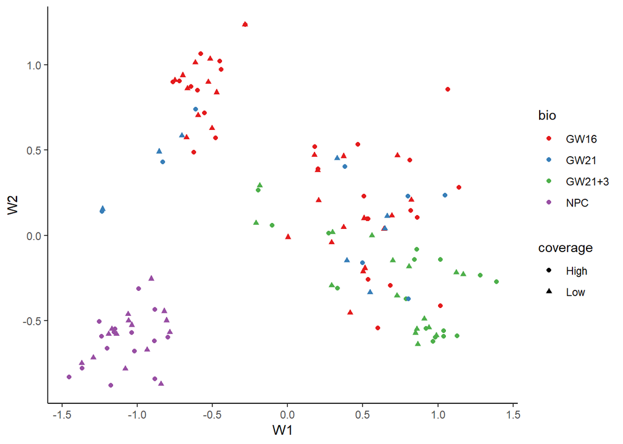

```r
fluidigm <- fluidigm[names(vars)[1:100],]

## ----rename----------------------------------------------------------------
assayNames(fluidigm)[1] <- "counts"

## ----zinbwave--------------------------------------------------------------
fluidigm_zinb <- zinbwave(fluidigm, K = 2, epsilon=1000)

## ----zinb_plot-------------------------------------------------------------
W <- reducedDim(fluidigm_zinb)

data.frame(W, bio=colData(fluidigm)$Biological_Condition,
           coverage=colData(fluidigm)$Coverage_Type) %>%
  ggplot(aes(W1, W2, colour=bio, shape=coverage)) + geom_point() +
  scale_color_brewer(type = "qual", palette = "Set1") + theme_classic()
```

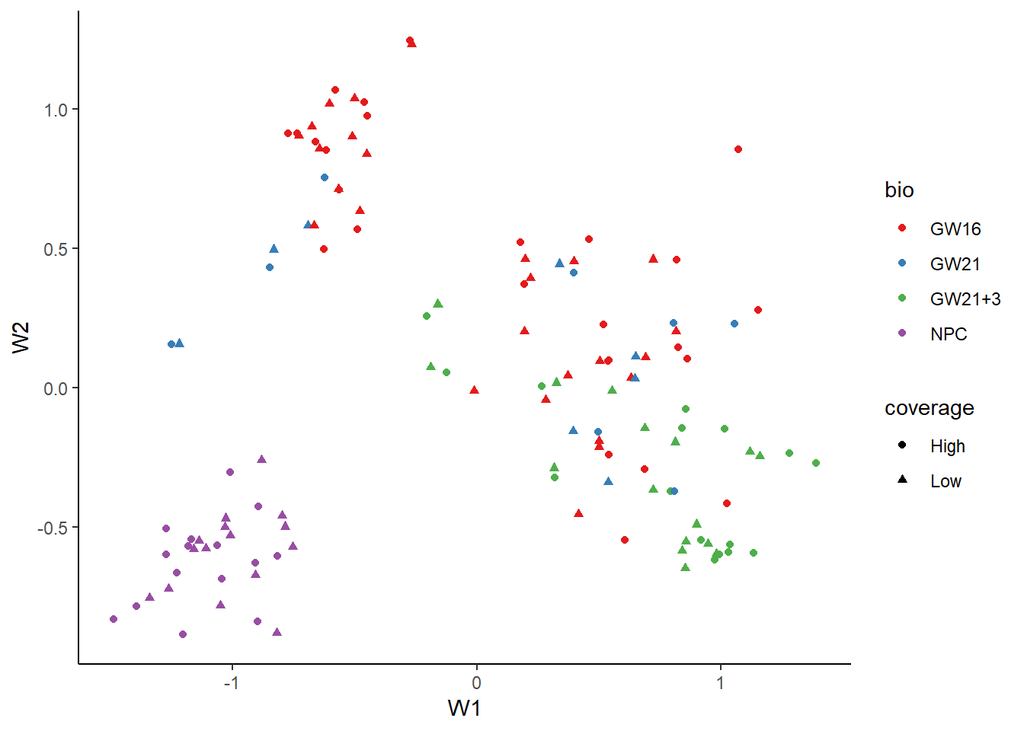

```r
## ----zinb_coverage---------------------------------------------------------
fluidigm_cov <- zinbwave(fluidigm, K=2, X="~Coverage_Type", epsilon=1000)

## ----zinb_plot2------------------------------------------------------------
W <- reducedDim(fluidigm_cov)

data.frame(W, bio=colData(fluidigm)$Biological_Condition,
           coverage=colData(fluidigm)$Coverage_Type) %>%
  ggplot(aes(W1, W2, colour=bio, shape=coverage)) + geom_point() +
  scale_color_brewer(type = "qual", palette = "Set1") + theme_classic()
```

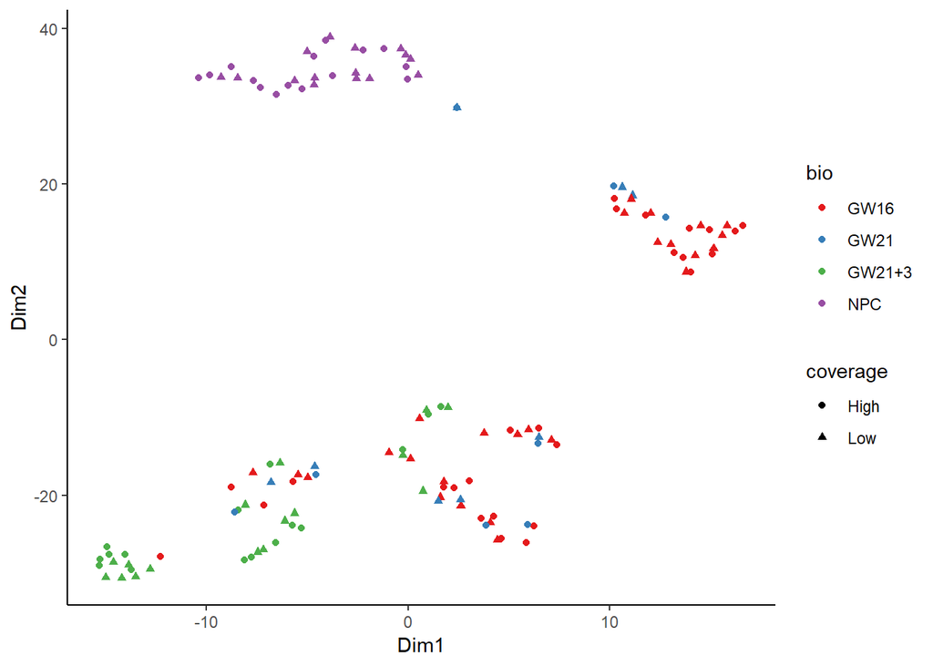

```r
## ----tsne------------------------------------------------------------------
set.seed(93024)

library(Rtsne)
W <- reducedDim(fluidigm_cov)
tsne_data <- Rtsne(W, pca = FALSE, perplexity=10, max_iter=5000)

data.frame(Dim1=tsne_data$Y[,1], Dim2=tsne_data$Y[,2],
           bio=colData(fluidigm)$Biological_Condition,
           coverage=colData(fluidigm)$Coverage_Type) %>%
  ggplot(aes(Dim1, Dim2, colour=bio, shape=coverage)) + geom_point() +
  scale_color_brewer(type = "qual", palette = "Set1") + theme_classic()
```

```r
## ----zinb------------------------------------------------------------------
zinb <- zinbFit(fluidigm, K=2, epsilon=1000)

## ----zinbwave2-------------------------------------------------------------
fluidigm_zinb <- zinbwave(fluidigm, fitted_model = zinb, K = 2, epsilon=1000)
```

## Seurat

Build the Seurat object

```r
library(Seurat)

seu <- CreateSeuratObject(raw.data = counts(fluidigm_zinb))


dim_jp <- reducedDim(fluidigm_zinb, "zinbwave")

seu <- SetDimReduction(object = seu, reduction.type = "zinbwave",
                       slot = "cell.embeddings",
                       new.data = dim_jp)

seu <- SetDimReduction(object = seu, reduction.type = "zinbwave", slot = "key",
                       new.data = "zinbwave")

seu <- FindClusters(object = seu, reduction.type = "zinbwave",
                    dims.use = 1:2, #this should match K
                    resolution = 0.6, print.output = 1, save.SNN = TRUE)
```

and do Seurat things with it:

```r
# JP
jp <- seu

rownames(x = jp@data)
```

```
##   [1] "IGFBPL1"   "STMN2"     "EGR1"      "ANP32E"    "CENPF"
##   [6] "LDHA"      "NFIA"      "SHISA2"    "KPNA2"     "HMGB2"
##  [11] "FOS"       "TOP2A"     "BAG4"      "TRIM59"    "ENO1"
##  [16] "DCX"       "CXADR"     "TLK1"      "VIM"       "BCAT1"
##  [21] "NUSAP1"    "ETNK1"     "SLC35F1"   "TGFBR1"    "AMER2"
##  [26] "CDV3"      "ITGB8"     "ANXA2"     "XRCC6"     "CACUL1"
##  [31] "EIF4B"     "SPARC"     "CHP1"      "SOX9"      "TMPO"
##  [36] "RND3"      "ZC3HAV1L"  "CSRP2"     "MLLT11"    "PRKCA"
##  [41] "NNAT"      "GPM6A"     "PHACTR1"   "SC5D"      "LINC01102"
##  [46] "SLC39A10"  "STON2"     "REEP3"     "EAF1"      "SFRP1"
##  [51] "MIR100HG"  "BCL11A"    "CD59"      "PTN"       "BROX"
##  [56] "FZD3"      "SOX2-OT"   "LCLAT1"    "IRF2BP2"   "VCAN"
##  [61] "HSPA5"     "EIF3E"     "CDO1"      "RTN1"      "SLA"
##  [66] "SERINC5"   "USP31"     "CCNG1"     "PHLDA1"    "IDH1"
##  [71] "BIRC5"     "ZNF207"    "FDFT1"     "ARF6"      "NFIB"
##  [76] "MN1"       "PIP4K2A"   "CKAP5"     "SDCBP"     "RELL1"
##  [81] "USP47"     "UQCRC1"    "ST8SIA1"   "ELMSAN1"   "DDAH1"
##  [86] "MIER1"     "TMEM33"    "EIF3L"     "THUMPD1"   "PDS5B"
##  [91] "SKIL"      "CLU"       "BUB3"      "INO80D"    "HACD3"
##  [96] "KIDINS220" "SBNO1"     "UBE4A"     "SRSF7"     "FAM117B"
```

```r
dim(jp@data)
```

```
## [1] 100 130
```

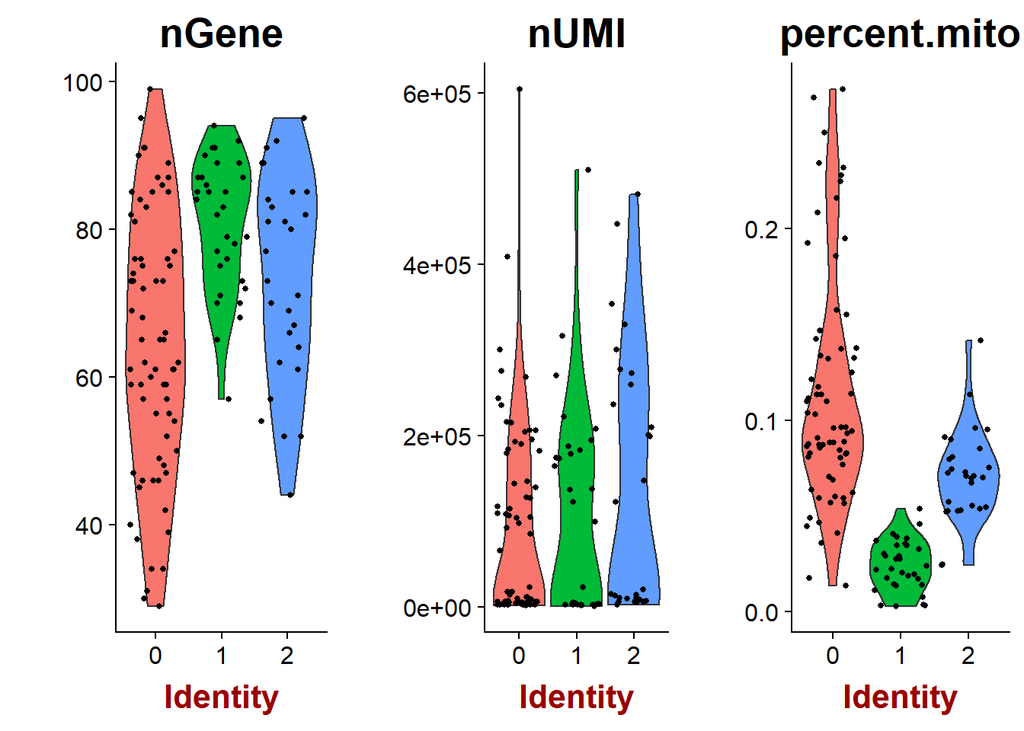

```r
mito.genes <- grep(pattern = "^N", x = rownames(x = jp@data), value = TRUE)
percent.mito <- Matrix::colSums(jp@raw.data[mito.genes, ])/Matrix::colSums(jp@raw.data)
jp <- AddMetaData(object = jp, metadata = percent.mito, col.name = "percent.mito")
VlnPlot(object = jp, features.plot = c("nGene", "nUMI", "percent.mito"), nCol = 3)
```

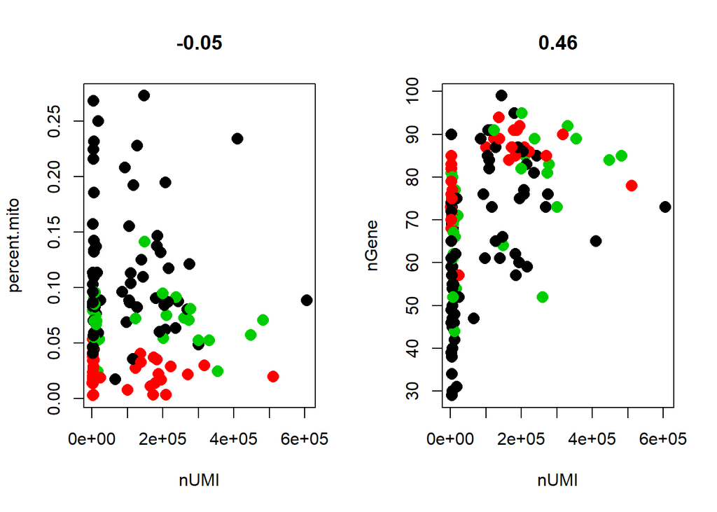

```r
par(mfrow = c(1, 2))
GenePlot(object = jp, gene1 = "nUMI", gene2 = "percent.mito")
GenePlot(object = jp, gene1 = "nUMI", gene2 = "nGene")
```

```r
# didn't filter b/c there aren't really any mito genes
#jp <- FilterCells(object = jp, subset.names = c("nGene", "percent.mito"),
#                    low.thresholds = c(200, -Inf), high.thresholds = c(2500, 0.05))

# normalize data
jp <- NormalizeData(object = jp, normalization.method = "LogNormalize",
                      scale.factor = 10000)
# scale data
jp <- ScaleData(object = jp, vars.to.regress = c("nUMI", "percent.mito"))
```

```
## [1] "Regressing out nUMI"         "Regressing out percent.mito"
##
## Time Elapsed:  3.56596803665161 secs
## [1] "Scaling data matrix"
##
```

```r
jp <- FindVariableGenes(object = jp, mean.function = ExpMean, dispersion.function = LogVMR)

jp <- RunPCA(object = jp, pc.genes = jp@var.genes, do.print = TRUE, pcs.print = 1:5,
               genes.print = 5)
```

```
## [1] "PC1"
## [1] "BCL11A" "AMER2"  "INO80D" "PHLDA1" "RND3"
## [1] ""
## [1] "ANXA2"  "CLU"    "DDAH1"  "PTN"    "SHISA2"
## [1] ""
## [1] ""
## [1] "PC2"
## [1] "EAF1"   "PRKCA"  "INO80D" "ANXA2"  "DDAH1"
## [1] ""
## [1] "ST8SIA1" "RELL1"   "AMER2"   "PTN"     "PHLDA1"
## [1] ""
## [1] ""
## [1] "PC3"
## [1] "PHLDA1" "EAF1"   "CLU"    "PTN"    "RND3"
## [1] ""
## [1] "SHISA2" "USP47"  "RELL1"  "BCL11A" "AMER2"
## [1] ""
## [1] ""
## [1] "PC4"
## [1] "EAF1"   "RELL1"  "PHLDA1" "SHISA2" "USP47"
## [1] ""
## [1] "PRKCA"   "CDO1"    "DDAH1"   "ST8SIA1" "AMER2"
## [1] ""
## [1] ""
## [1] "PC5"
## [1] "RND3"  "USP47" "AMER2" "ANXA2" "CLU"
## [1] ""
## [1] "CDO1"   "EAF1"   "PRKCA"  "BCL11A" "INO80D"
## [1] ""
## [1] ""
```

[figure not shown]

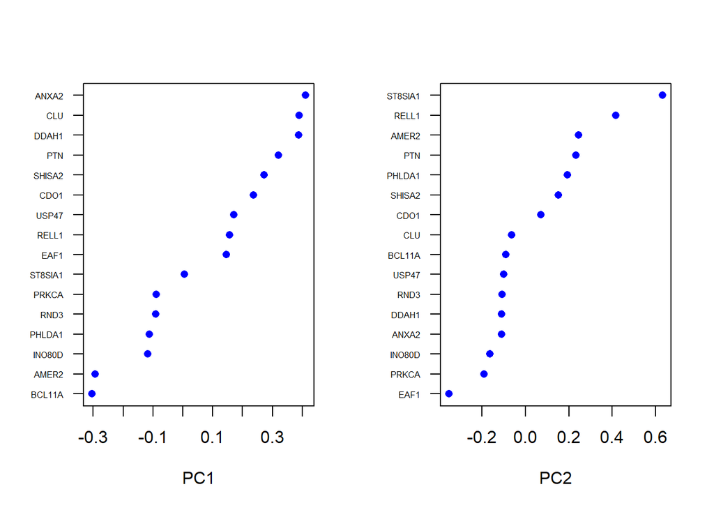

```r
jp <- ProjectPCA(object = jp, do.print = FALSE)

VizPCA(object = jp, pcs.use = 1:2)
```

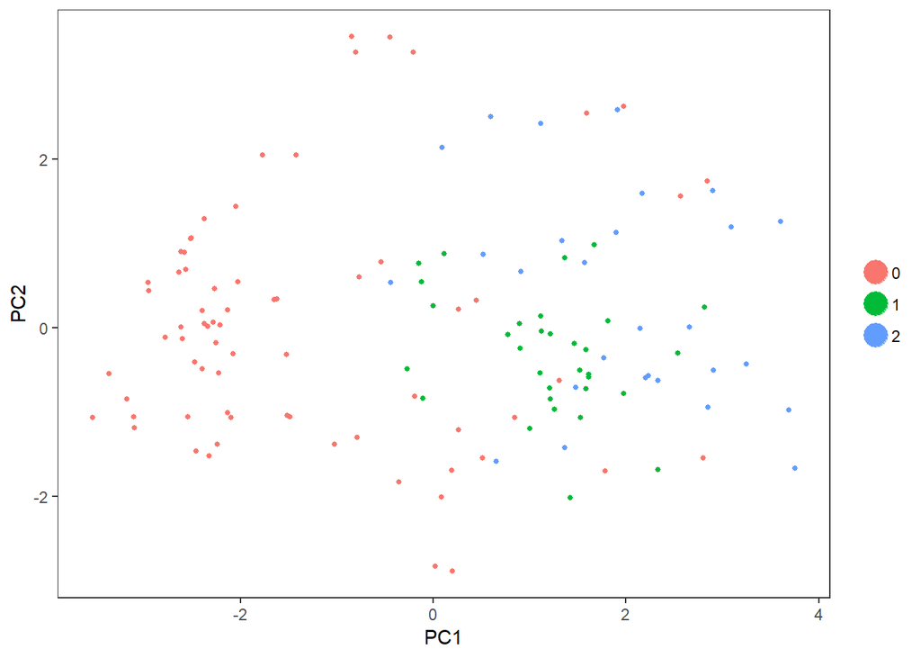

```r
PCAPlot(object = jp, dim.1 = 1, dim.2 = 2)
```